```python
cd C:\Users\Ramiro Gonzalez\Desktop\POLI127DATA\json files
```

```
C:\Users\Ramiro Gonzalez\Desktop\POLI127DATA\json files
```

# POLI 127 Data Analyst Role

## Ramiro Gonzalez and Melissa Becerra

```python
import pandas as pd
import matplotlib.pyplot as plt
import numpy as np
import csv
import json
from IPython.display import Image
import math
from pandas import DataFrame as df
from scipy.stats import trim_mean, kurtosis
from scipy.stats.mstats import mode, gmean, hmean
from scipy import interpolate
```

# Link

https://github.com/impracticaldev/Political-Science/tree/master/POLI127/Projects/Data-Analyst-Role

## Curated data

Independent Variable 1: Income_same_sex_couple to be determined.  
Independent Variable 2 (NOTE: This may be used as variable): Same_sex_couple_who_are_same_sex_spouses_for_years_2005_2016 was original in percentage, it was converted to quantity by using $FLOOR((x,y)\cdot(x_2,y_2))$  
Independent Variable 3Total_same_sex_couple_year_2005_201  
Independent Variable 4:Total_adoption_by_each_state. Interpolation may be neccessary since Independent variable 1,2, and 3, are of the following years: 2005 - 2016. Variable 4 consist of the following years: 1990,2000,2001,2005,2007,2008,2009,2010,2011,2012  
Linear Interpolation $y = y_1 + \frac{y_2 - y_1}{x_2 - x_1}(x -x_1) $  
Dependent Variable The rate of adoption. May be theoretically computed for missing years using interpolation for independent variable 4.

## Miscellaneous

Total number of same sex households

# Documentation

## Three Casual Models

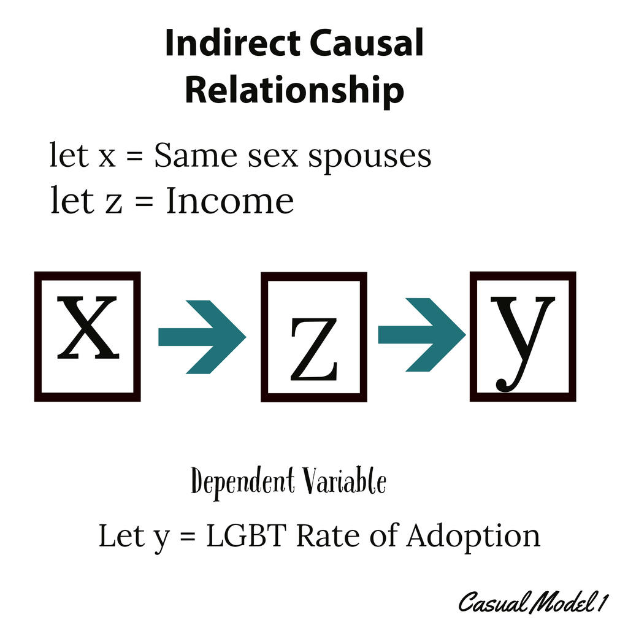

```python
Image(filename="img/CasualModel1.png",width=400,height=500)
```

Having a spouse increases the chance of adoption.Income may be the hidden factor that causes this relationship since both partners may be bringing home income. (Income is the mediating variable)

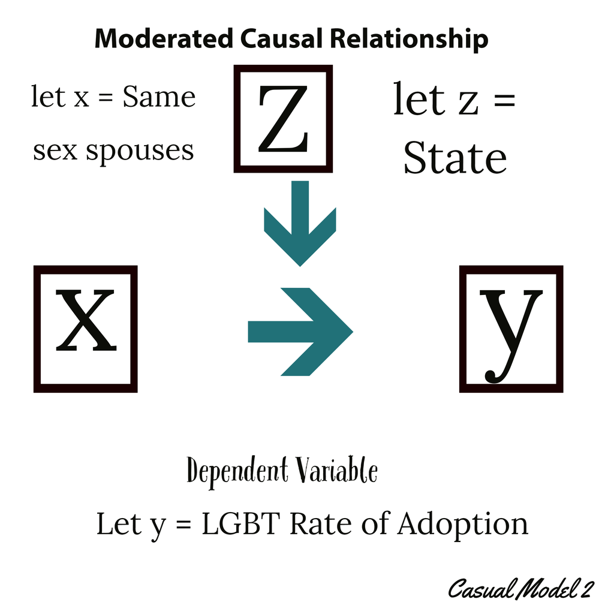

```python
Image(filename="img/CasualModel2.jpg",width=400,height=500)
```

Same sex spouses adopt at a higher rate, but the only way to be spouse it must be established by law, which means marriage must be legal in the state one resides to be considered a "spouse".

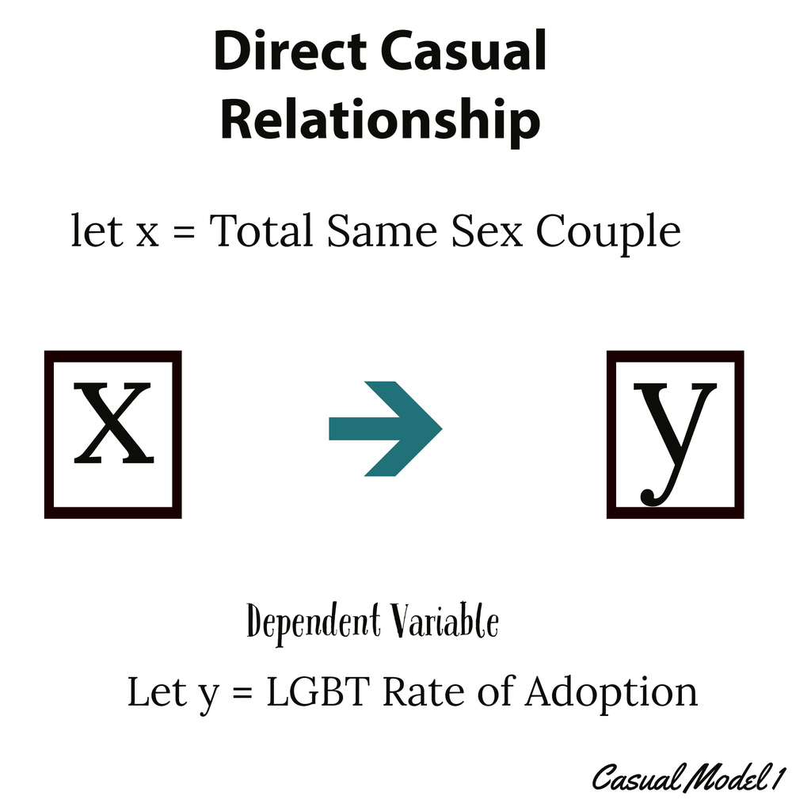

```python
Image(filename="img/CasualModel3.jpg",width=400,height=500)
```

## Read In Data

Saving the the data above in seperate variable. Possible variable names are as follow independentOne, independentTwo, independent3, independent4

```python
#Using json files, option one, csv converted to json
pathvar1 = "Income_same_sex_couple.json"
samesexhouseholds = "samesexhouseholds.json"
pathvar2 = "Same_sex_couple_who_are_same_sex_spouses_for_years_2005_2016.json"
pathvar3 = "Total_same_sex_couple_year_2005_2016.json"
pathvar4 = "Total_adoption_by_each_state.json"
```

```python
cd C:\Users\Ramiro Gonzalez\Desktop\POLI127DATA\csv
```

```
C:\Users\Ramiro Gonzalez\Desktop\POLI127DATA\csv
```

```python
#income was originally in percentage
#importing to csv, analysis may be easier this way.
pathvar1csv = "Income_same_sex_couple.csv"
sameSexHouseholdsTcsv = "samesexhouseholdsT.csv"
sameSexHouseholdscsv = "samesexhouseholds.csv"
pathVar2csv = "Same_sex_couple_who_are_same_sex_spouses_for_years_2005_2016.csv"
pathVar3csv = "Total_same_sex_couple_year_2005_2016.csv"
pathVar4csv = "Total_adoption_by_each_state.csv"
```

```python
income_couples = pd.read_csv(pathvar1csv) #DONE
same_sex_householdT = pd.read_csv(sameSexHouseholdsTcsv) #DONE
same_sex_household = pd.read_csv(sameSexHouseholdscsv) #DONE
same_sex_spouses = pd.read_csv(pathVar2csv) #DONE
total_same_sex_couple = pd.read_csv(pathVar3csv)
total_pop_each_state = pd.read_csv(pathVar4csv)
```

```python
income_couples.head()
```

|  | ID | Income | 2016 | 2015 | 2014 | 2013 | 2012 | 2012.1 | 2011 | 2010 | 2009 | 2008 | 2007 | 2006 | 2005 |
| --- | --- | --- | --- | --- | --- | --- | --- | --- | --- | --- | --- | --- | --- | --- | --- |
| 0 | 35 | Less than 35,000 | 115369 | 120245 | 109634 | 145320 | 95910 | 193751 | 193751.04 | 93008 | 87195 | 84670 | 113042.70 | 124778.72 | 139849.74 |
| 1 | 49 | 35,000 to 49,999 | 79871 | 85889 | 78310 | 72660 | 63940 | 96875 | 96875.00 | 58130 | 58130 | 56447 | 75361.80 | 85785.37 | 101002.59 |
| 2 | 74 | 50,000 to 74,999 | 150867 | 146012 | 125296 | 130788 | 108698 | 127149 | 127149.00 | 104634 | 110447 | 101605 | 150723.60 | 155973.40 | 163158.03 |
| 3 | 99 | 75,000 to 99,999 | 133118 | 128834 | 117465 | 108990 | 89516 | 72656 | 72656.00 | 87195 | 87195 | 84670 | 120578.88 | 124778.72 | 124310.88 |
| 4 | 100 | 100,000 or more | 390480 | 360736 | 336733 | 254310 | 255760 | 96875 | 96875.00 | 226707 | 220894 | 225789 | 278838.66 | 265154.78 | 233082.90 |

```python
same_sex_spouses.head()
```

|  | 2016 | 2015 | 2014 | 2013 | 2012 | 2011 | 2010 | 2009 | 2008 | 2007 | 2006 | 2005 |
| --- | --- | --- | --- | --- | --- | --- | --- | --- | --- | --- | --- | --- |
| 0 | 3903 | 4258 | 2936 | 2905 | 2716 | 1625 | 1777 | 1865 | 1857 | 4234 | 6312 | 5617 |
| 1 | 1073 | 694 | 497 | 171 | 275 | 114 | 355 | 194 | 276 | 573 | 492 | 527 |
| 2 | 10885 | 7356 | 5937 | 3869 | 3347 | 2659 | 2634 | 2271 | 2384 | 7362 | 7248 | 6162 |
| 3 | 2228 | 3097 | 2461 | 1025 | 1167 | 947 | 975 | 1017 | 1159 | 3655 | 3397 | 4181 |
| 4 | 73920 | 67153 | 53336 | 40280 | 27679 | 29171 | 28897 | 28110 | 23377 | 35815 | 40992 | 43216 |

```python
total_same_sex_couple.head()
```

|  | Unnamed: 0 | 2016 | 2015 | 2014 | 2013 | 2012 | 2011 | 2010 | 2009 | 2008 | 2007 | 2006 | 2005 |
| --- | --- | --- | --- | --- | --- | --- | --- | --- | --- | --- | --- | --- | --- |
| 0 | Alabama | 7,885 | 7,814 | 6,797 | 7,157 | 6,274 | 6,180 | 5,452 | 4,527 | 4,850 | 7,589 | 9,594 | 8,602 |
| 1 | Alaska | 1,952 | 1,359 | 1,816 | 982 | 1,108 | 828 | 752 | 1,136 | 854 | 1,462 | 1,003 | 1,644 |
| 2 | Arizona | 20,656 | 20,781 | 17,515 | 17,352 | 17,169 | 13,641 | 15,143 | 14,375 | 12,960 | 17,827 | 15,164 | 16,931 |
| 3 | Arkansas | 5,099 | 5,501 | 5,399 | 4,928 | 3,706 | 2,526 | 4,015 | 3,769 | 3,176 | 6,228 | 4,752 | 5,890 |
| 4 | California | 128,111 | 120,998 | 109,296 | 107,991 | 89,001 | 87,078 | 90,023 | 81,954 | 84,397 | 104,723 | 108,734 | 107,772 |

```python
total_pop_each_state.head()
#this will be a poblem in our anaysis, 1990 - 2012, use interpolation and reorder
```

|  | State | 1990 | 2000 | 2001 | 2005 | 2007 | 2008 | 2009 | 2010 | 2011 | 2012 |
| --- | --- | --- | --- | --- | --- | --- | --- | --- | --- | --- | --- |
| 0 | Alabama | 1,907 | 2,009 | 1,857 | 2,093 | 2,298 | 2,252 | 2461 | 1813 | 2140 | 2590 |
| 1 | Alaska | 611 | 634 | 616 | 631 | 618 | 643 | 767 | 713 | 714 | 699 |
| 2 | Arizona | 1,541 | 1,736 | 1,642 | 1953 | 2,491 | 2,907 | 2373 | 2581 | 2571 | 2688 |
| 3 | Arkansas | 1,671 | 1,907 | 1,698 | 2055 | 2,014 | 2,133 | 2352 | 2233 | 2122 | 2236 |
| 4 | California | 126,082 | 90,541 | 9,202 | 11034 | 13,889 | 12,207 | 9982 | 9,247 | 7603 | 7253 |

## Obtain Summary/Descriptive Statistics

## Independent Variable 1

Income of same sex couples.

The following will be calculated for mean, sd, var, min, max, median, range, and quantile. In my analysis of variable 1 (Income_same_sex_couples) I want to find the mean, this will show the relative income bracket smae sex couple fall into. The above "Income" bracket is of importance here.

```python
#find the mean, for each year
#mean, sd, var, min, max, median, range, and quantile.
stdDevEachYear,minEachYear,meanEachYear,maxEachYear,rangeEachYear = ({} for i in range(5))
for i in range(5,17):
    meanEachYear[("mean{}".format(i + 2000))] = income_couples['{}'.format(i + 2000)].mean()
    stdDevEachYear[("stdDev{}".format(i + 2000))] = income_couples['{}'.format(i + 2000)].std()
    minEachYear[("min{}".format(i + 2000))] = income_couples['{}'.format(i + 2000)].min()
    maxEachYear[("max{}".format(i + 2000))] = income_couples['{}'.format(i + 2000)].max()
print("#The mean, so called average.")
print(meanEachYear)
print("#The standard deviation.")
print(stdDevEachYear) #The standard deviation
print("#The min and max.")
print(minEachYear)
print(maxEachYear)
print("#Range is max - min.")
for i in range(5,17):
    rangeEachYear[("range{}".format(i + 2000))] = maxEachYear[("max{}".format(i + 2000))] - minEachYear[("min{}".format(i + 2000))]
print(rangeEachYear)
income_couples.describe()
```

```
#The mean, so called average.
{'mean2005': 152280.828, 'mean2006': 151294.198, 'mean2007': 147709.12799999997, 'mean2008': 110636.2, 'mean2009': 112772.2, 'mean2010': 113934.8, 'mean2011': 117461.20800000001, 'mean2012': 122764.8, 'mean2013': 142413.6, 'mean2014': 153487.6, 'mean2015': 168343.2, 'mean2016': 173941.0}
#The standard deviation.
{'stdDev2005': 50531.16858735082, 'stdDev2006': 68344.11964062104, 'stdDev2007': 78064.05808619302, 'stdDev2008': 66382.76584099219, 'stdDev2009': 63225.561545153556, 'stdDev2010': 65328.396465090125, 'stdDev2011': 46821.68932232498, 'stdDev2012': 76112.7751510875, 'stdDev2013': 68277.20670033302, '…
#The min and max.
{'min2005': 101002.59, 'min2006': 85785.37, 'min2007': 75361.8, 'min2008': 56447, 'min2009': 58130, 'min2010': 58130, 'min2011': 72656.0, 'min2012': 63940, 'min2013': 72660, 'min2014': 78310, 'min2015': 85889, 'min2016': 79871}
{'max2005': 233082.9, 'max2006': 265154.78, 'max2007': 278838.66, 'max2008': 225789, 'max2009': 220894, 'max2010': 226707, 'max2011': 193751.04, 'max2012': 255760, 'max2013': 254310, 'max2014': 336733, 'max2015': 360736, 'max2016': 390480}
#Range is max - min.
{'range2005': 132080.31, 'range2006': 179369.41000000003, 'range2007': 203476.86, 'range2008': 169342, 'range2009': 162764, 'range2010': 168577, 'range2011': 121095.04000000001, 'range2012': 191820, 'range2013': 181650, 'range2014': 258423, 'range2015': 274847, 'range2016': 310609}
```

|  | ID | 2016 | 2015 | 2014 | 2013 | 2012 | 2012.1 | 2011 | 2010 | 2009 | 2008 | 2007 | 2006 | 2005 |
| --- | --- | --- | --- | --- | --- | --- | --- | --- | --- | --- | --- | --- | --- | --- |
| count | 5.000000 | 5.000000 | 5.000000 | 5.000000 | 5.0000 | 5.000000 | 5.000000 | 5.000000 | 5.000000 | 5.000000 | 5.000000 | 5.000000 | 5.000000 | 5.000000 |
| mean | 71.400000 | 173941.000000 | 168343.200000 | 153487.600000 | 142413.6000 | 122764.800000 | 117461.200000 | 117461.208000 | 113934.800000 | 112772.200000 | 110636.200000 | 147709.128000 | 151294.198000 | 152280.828000 |
| std | 29.211299 | 123862.735932 | 109757.438029 | 103978.459809 | 68277.2067 | 76112.775151 | 46821.673029 | 46821.689322 | 65328.396465 | 63225.561545 | 66382.765841 | 78064.058086 | 68344.119641 | 50531.168587 |
| min | 35.000000 | 79871.000000 | 85889.000000 | 78310.000000 | 72660.0000 | 63940.000000 | 72656.000000 | 72656.000000 | 58130.000000 | 58130.000000 | 56447.000000 | 75361.800000 | 85785.370000 | 101002.590000 |
| 25% | 49.000000 | 115369.000000 | 120245.000000 | 109634.000000 | 108990.0000 | 89516.000000 | 96875.000000 | 96875.000000 | 87195.000000 | 87195.000000 | 84670.000000 | 113042.700000 | 124778.720000 | 124310.880000 |
| 50% | 74.000000 | 133118.000000 | 128834.000000 | 117465.000000 | 130788.0000 | 95910.000000 | 96875.000000 | 96875.000000 | 93008.000000 | 87195.000000 | 84670.000000 | 120578.880000 | 124778.720000 | 139849.740000 |
| 75% | 99.000000 | 150867.000000 | 146012.000000 | 125296.000000 | 145320.0000 | 108698.000000 | 127149.000000 | 127149.000000 | 104634.000000 | 110447.000000 | 101605.000000 | 150723.600000 | 155973.400000 | 163158.030000 |
| max | 100.000000 | 390480.000000 | 360736.000000 | 336733.000000 | 254310.0000 | 255760.000000 | 193751.000000 | 193751.040000 | 226707.000000 | 220894.000000 | 225789.000000 | 278838.660000 | 265154.780000 | 233082.900000 |

The above data is stored meanEachYear. We may also get the percentage of couples that fall in the mean.

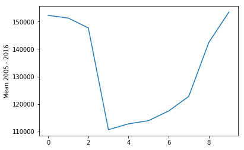

```python
meanEachYearPlotted = []
for i in range(0,10):
    meanEachYearPlotted.append(meanEachYear["mean{}".format(i + 2005)])
plt.plot(meanEachYearPlotted)
plt.ylabel('Mean 2005 - 2016')
#The graph below goes from 2005 - 2016 , Increment 2005 + xlabel , that is 0 is 2005, 1 is 2006 ... etc
plt.show()
```

## Independent variable 2

We consider the following. The Total Same Sex Couple Households. This are our potential adopters.

```python
same_sex_householdT.head()
```

|  | Year | Total Households |
| --- | --- | --- |
| 0 | 2005 | 776943 |
| 1 | 2006 | 779867 |
| 2 | 2007 | 753618 |
| 3 | 2008 | 564473 |
| 4 | 2009 | 581300 |

```python
#The following describes from 2005-2016
same_sex_householdT.describe()
#The year portion provides very little information.
```

|  | Year | Total Households |
| --- | --- | --- |
| count | 12.000000 | 12.000000 |
| mean | 2010.500000 | 712537.416667 |
| std | 3.605551 | 111898.249764 |
| min | 2005.000000 | 564473.000000 |
| 25% | 2007.750000 | 602435.000000 |
| 50% | 2010.500000 | 740109.000000 |
| 75% | 2013.250000 | 780675.250000 |
| max | 2016.000000 | 887456.000000 |

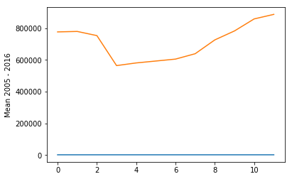

```python
#Plotting the same_sex_household
plt.plot(same_sex_householdT)
plt.ylabel('Mean 2005 - 2016')
#The graph below goes from 2005 - 2016 , Increment 2005 + xlabel , that is 0 is 2005, 1 is 2006 ... etc
plt.show()
```

Within the subset of $\textbf{total households}$ there exists same_sex_spouses. Note that $\textbf{Total households}$ includes same sex couples who are in a partnership or relationship, but also spouses under the law. We are interested in housholds with same sex spouses because they are more likely to adopt, or so our data will show.

```python
same_sex_spouses.head()
```

|  | 2016 | 2015 | 2014 | 2013 | 2012 | 2011 | 2010 | 2009 | 2008 | 2007 | 2006 | 2005 |
| --- | --- | --- | --- | --- | --- | --- | --- | --- | --- | --- | --- | --- |
| 0 | 3903 | 4258 | 2936 | 2905 | 2716 | 1625 | 1777 | 1865 | 1857 | 4234 | 6312 | 5617 |
| 1 | 1073 | 694 | 497 | 171 | 275 | 114 | 355 | 194 | 276 | 573 | 492 | 527 |
| 2 | 10885 | 7356 | 5937 | 3869 | 3347 | 2659 | 2634 | 2271 | 2384 | 7362 | 7248 | 6162 |
| 3 | 2228 | 3097 | 2461 | 1025 | 1167 | 947 | 975 | 1017 | 1159 | 3655 | 3397 | 4181 |
| 4 | 73920 | 67153 | 53336 | 40280 | 27679 | 29171 | 28897 | 28110 | 23377 | 35815 | 40992 | 43216 |

For this to work we must remove the states, and knowing that states are in alphabetical order Alabam = 0 .. Wyoming = 50 We will transpose the data below, so that we are able to describe it, removing the header manually was not possible.

# originally 2010 had a missing value, recall this is same sex couples, to be retrieve from orginial data. There was missing value in orginial data, therefore interpolation may be neccesary.

$f(x) = \sum f_{j} \phi(x -x_j)$ The mean would be sufficient.

```python
#Begin by storing data
y = [615,441,372,635,179,222,296,475,796,738,952]
mean = []
sumY = 0;
for i in range(0,11):
    sumY = sumY + y[i]
mean = sumY/12;
print(mean)
```

```
476.75
```

```python
total_same_sex_spouse_each_year = {};
for i in range(16,5,-1):
    total_same_sex_spouse_each_year[('total_spouses{}'.format(2000 + i))] = same_sex_spouses['{}'.format(2000 + i)].sum()
print(total_same_sex_spouse_each_year)
```

```
{'total_spouses2016': 486978, 'total_spouses2015': 425173, 'total_spouses2014': 334901, 'total_spouses2013': 251597, 'total_spouses2012': 181961, 'total_spouses2011': 168081, 'total_spouses2010': 152746, 'total_spouses2009': 152080, 'total_spouses2008': 149917, 'total_spouses2007': 340861, 'total_sp…
```

```python
same_sex_spouses.describe()
#The descriptions are specific to entire united states, that is 51 states, for years 2016 - 2005
```

|  | 2016 | 2015 | 2014 | 2013 | 2012 | 2011 | 2010 | 2009 | 2008 | 2007 | 2006 | 2005 |
| --- | --- | --- | --- | --- | --- | --- | --- | --- | --- | --- | --- | --- |
| count | 51.000000 | 51.000000 | 51.000000 | 51.000000 | 51.000000 | 51.000000 | 51.000000 | 51.000000 | 51.000000 | 51.00000 | 51.000000 | 51.000000 |
| mean | 9548.588235 | 8336.725490 | 6566.686275 | 4933.274510 | 3567.862745 | 3295.705882 | 2995.019608 | 2981.960784 | 2939.549020 | 6683.54902 | 7562.392157 | 7692.156863 |
| std | 12624.194422 | 11001.608239 | 8734.323613 | 6803.270352 | 4708.409409 | 4685.072073 | 4446.052791 | 4305.319026 | 3845.748886 | 6854.02614 | 7782.117663 | 8116.400134 |
| min | 610.000000 | 441.000000 | 331.000000 | 171.000000 | 179.000000 | 114.000000 | 210.000000 | 194.000000 | 177.000000 | 573.00000 | 492.000000 | 527.000000 |
| 25% | 2367.000000 | 2432.500000 | 2140.500000 | 1447.000000 | 1159.000000 | 929.000000 | 885.000000 | 888.500000 | 721.000000 | 1813.00000 | 2150.000000 | 2285.000000 |
| 50% | 5382.000000 | 4551.000000 | 4161.000000 | 2619.000000 | 2018.000000 | 1777.000000 | 1716.000000 | 1782.000000 | 1857.000000 | 4601.00000 | 5231.000000 | 5300.000000 |
| 75% | 11594.000000 | 10250.000000 | 7671.000000 | 5672.000000 | 4294.500000 | 3611.500000 | 3239.000000 | 3047.000000 | 3030.500000 | 8683.00000 | 9597.500000 | 10368.000000 |
| max | 73920.000000 | 67153.000000 | 53336.000000 | 40280.000000 | 27679.000000 | 29171.000000 | 28897.000000 | 28110.000000 | 23377.000000 | 35815.00000 | 40992.000000 | 43216.000000 |

If need it be for every state we whould do the following.

```python
# we transpose it and calculate the statistics for every state, as follows.
(same_sex_spouses.T).describe()
```

|  | 0 | 1 | 2 | 3 | 4 | 5 | 6 | 7 | 8 | 9 | ... | 41 | 42 | 43 | 44 | 45 | 46 | 47 | 48 | 49 | 50 |
| --- | --- | --- | --- | --- | --- | --- | --- | --- | --- | --- | --- | --- | --- | --- | --- | --- | --- | --- | --- | --- | --- |
| count | 12.000000 | 12.00000 | 12.000000 | 12.000000 | 12.000000 | 12.000000 | 12.000000 | 12.000000 | 12.000000 | 12.000000 | ... | 12.000000 | 12.000000 | 12.000000 | 12.000000 | 12.000000 | 12.000000 | 12.000000 | 12.000000 | 12.000000 | 12.000000 |
| mean | 3333.750000 | 436.75000 | 5176.166667 | 2109.083333 | 40995.500000 | 4903.666667 | 4512.416667 | 1119.416667 | 1366.166667 | 17516.333333 | ... | 606.416667 | 4989.583333 | 18250.083333 | 2189.833333 | 1187.500000 | 6892.083333 | 7886.500000 | 1338.666667 | 4545.416667 | 516.416667 |
| std | 1551.447953 | 269.13806 | 2731.183721 | 1215.432468 | 16216.643883 | 3014.856467 | 1121.090091 | 671.995868 | 1087.502379 | 9446.391532 | ... | 203.503611 | 2651.329802 | 9070.256551 | 1138.081067 | 537.738446 | 3371.901499 | 5063.629573 | 822.887856 | 2343.357011 | 237.369470 |
| min | 1625.000000 | 114.00000 | 2271.000000 | 947.000000 | 23377.000000 | 1843.000000 | 2375.000000 | 494.000000 | 210.000000 | 8147.000000 | ... | 295.000000 | 2060.000000 | 8302.000000 | 308.000000 | 610.000000 | 3160.000000 | 2459.000000 | 307.000000 | 2053.000000 | 179.000000 |
| 25% | 1863.000000 | 254.75000 | 2652.750000 | 1023.000000 | 28700.250000 | 2281.750000 | 3849.750000 | 632.000000 | 534.500000 | 9287.500000 | ... | 435.500000 | 2611.500000 | 9851.500000 | 1511.500000 | 708.000000 | 3806.000000 | 2995.500000 | 702.250000 | 2323.750000 | 353.000000 |
| 50% | 2920.500000 | 423.50000 | 4903.000000 | 1697.500000 | 38047.500000 | 4456.000000 | 4714.000000 | 912.500000 | 1176.500000 | 15883.500000 | ... | 626.500000 | 4156.000000 | 17656.500000 | 2070.500000 | 1107.000000 | 6470.500000 | 7906.000000 | 973.000000 | 4299.500000 | 475.500000 |
| 75% | 4240.000000 | 538.50000 | 7275.000000 | 3172.000000 | 45746.000000 | 6319.000000 | 5320.500000 | 1263.000000 | 1918.250000 | 22695.250000 | ... | 757.250000 | 6905.250000 | 26116.750000 | 3289.000000 | 1524.750000 | 9824.500000 | 10946.750000 | 2225.000000 | 6460.250000 | 660.750000 |
| max | 6312.000000 | 1073.00000 | 10885.000000 | 4181.000000 | 73920.000000 | 10112.000000 | 6126.000000 | 2324.000000 | 3729.000000 | 38956.000000 | ... | 931.000000 | 9667.000000 | 34703.000000 | 3823.000000 | 2380.000000 | 11885.000000 | 17196.000000 | 2574.000000 | 8051.000000 | 952.000000 |

8 rows × 51 columns

## Independent Variable 3

```python
total_same_sex_couple.head()
```

|  | Unnamed: 0 | 2016 | 2015 | 2014 | 2013 | 2012 | 2011 | 2010 | 2009 | 2008 | 2007 | 2006 | 2005 |
| --- | --- | --- | --- | --- | --- | --- | --- | --- | --- | --- | --- | --- | --- |
| 0 | Alabama | 7,885 | 7,814 | 6,797 | 7,157 | 6,274 | 6,180 | 5,452 | 4,527 | 4,850 | 7,589 | 9,594 | 8,602 |
| 1 | Alaska | 1,952 | 1,359 | 1,816 | 982 | 1,108 | 828 | 752 | 1,136 | 854 | 1,462 | 1,003 | 1,644 |
| 2 | Arizona | 20,656 | 20,781 | 17,515 | 17,352 | 17,169 | 13,641 | 15,143 | 14,375 | 12,960 | 17,827 | 15,164 | 16,931 |
| 3 | Arkansas | 5,099 | 5,501 | 5,399 | 4,928 | 3,706 | 2,526 | 4,015 | 3,769 | 3,176 | 6,228 | 4,752 | 5,890 |
| 4 | California | 128,111 | 120,998 | 109,296 | 107,991 | 89,001 | 87,078 | 90,023 | 81,954 | 84,397 | 104,723 | 108,734 | 107,772 |

```python
total_same_sex_couple.describe()
```

|  | Unnamed: 0 | 2016 | 2015 | 2014 | 2013 | 2012 | 2011 | 2010 | 2009 | 2008 | 2007 | 2006 | 2005 |
| --- | --- | --- | --- | --- | --- | --- | --- | --- | --- | --- | --- | --- | --- |
| count | 51 | 51 | 51 | 51 | 51 | 51 | 51 | 51 | 51 | 51 | 51 | 51 | 51 |
| unique | 51 | 51 | 51 | 51 | 50 | 51 | 51 | 51 | 51 | 51 | 51 | 51 | 51 |
| top | New Jersey | 1,650 | 14,602 | 13,140 | 1,183 | 1,372 | 413 | 6,347 | 13,512 | 4,820 | 4,320 | 6,404 | 14,722 |
| freq | 1 | 1 | 1 | 1 | 2 | 1 | 1 | 1 | 1 | 1 | 1 | 1 | 1 |

## Independent variable 4

Total adoption by each state.

```python
total_pop_each_state.head()
```

|  | State | 1990 | 2000 | 2001 | 2005 | 2007 | 2008 | 2009 | 2010 | 2011 | 2012 |
| --- | --- | --- | --- | --- | --- | --- | --- | --- | --- | --- | --- |
| 0 | Alabama | 1,907 | 2,009 | 1,857 | 2,093 | 2,298 | 2,252 | 2461 | 1813 | 2140 | 2590 |
| 1 | Alaska | 611 | 634 | 616 | 631 | 618 | 643 | 767 | 713 | 714 | 699 |
| 2 | Arizona | 1,541 | 1,736 | 1,642 | 1953 | 2,491 | 2,907 | 2373 | 2581 | 2571 | 2688 |
| 3 | Arkansas | 1,671 | 1,907 | 1,698 | 2055 | 2,014 | 2,133 | 2352 | 2233 | 2122 | 2236 |
| 4 | California | 126,082 | 90,541 | 9,202 | 11034 | 13,889 | 12,207 | 9982 | 9,247 | 7603 | 7253 |

```python
(total_pop_each_state['2007']).describe()
```

```
count        51
unique       51
top       4,973
freq          1
Name: 2007, dtype: object
```

# Analysis of 2007

```python
path2007 = 'IIIP.csv'
```

```python
IIP = pd.read_csv(path2007)
```

```python
IIP.head()
```

|  | State | Total Adopted | Adopted Children | Same Sex Spouse | Same Sex Couple |
| --- | --- | --- | --- | --- | --- |
| 0 | Alabama | 24944 | 301 | 4234 | 7,589 |
| 1 | Alaska | 691 | 594 | 573 | 1,462 |
| 2 | Arizona | 28966 | 543 | 7362 | 17,827 |
| 3 | Arkansas | 15973 | 1040 | 3655 | 6,228 |
| 4 | California | 167190 | 16458 | 35815 | 104,723 |

```python
independent1, independent2,independent3 = ([] for i in range(3))
independent1 = IIP['Total Adopted']
independent2 = IIP['Same Sex Spouse']
independent3 = IIP['Same Sex Couple']
dependent = IIP['Adopted Children']
```

## Cross Tabulation

```python
pd.crosstab(dependent, [independent1, independent2, independent3], rownames=['dependent'], colnames=['independent1', 'independent2','independent3'])
```

| independent1 independent2 independent3 dependent | 100736 19491 54,144 | 10588 3928 7,398 | 110275 21921 48,179 | 11764 1908 6,059 | 11812 2187 3,784 | 15973 3655 6,228 | 16300 3344 4,407 | 167190 35815 104,723 | 18569 3478 6,124 | 19239 4725 9,546 | ... | 62653 12336 24,973 | 6803 1058 1,831 | 6864 1344 3,643 | 691 573 1,462 | 6941 743 2,353 | 7137 1718 4,350 | 73638 13705 30,524 | 82179 21727 53,648 | 9562 1578 2,657 | 9849 2466 3,795 |
| --- | --- | --- | --- | --- | --- | --- | --- | --- | --- | --- | --- | --- | --- | --- | --- | --- | --- | --- | --- | --- | --- |
| 0 | 0 | 0 | 0 | 0 | 0 | 0 | 0 | 0 | 0 | 0 | ... | 0 | 0 | 1 | 0 | 0 | 0 | 0 | 0 | 1 | 1 |
| 95 | 0 | 0 | 0 | 0 | 0 | 0 | 0 | 0 | 1 | 0 | ... | 0 | 1 | 0 | 0 | 1 | 0 | 0 | 0 | 0 | 0 |
| 161 | 0 | 0 | 0 | 0 | 0 | 0 | 0 | 0 | 0 | 0 | ... | 0 | 0 | 0 | 0 | 0 | 0 | 0 | 0 | 0 | 0 |
| 176 | 0 | 0 | 0 | 0 | 0 | 0 | 0 | 0 | 0 | 0 | ... | 0 | 0 | 0 | 0 | 0 | 0 | 0 | 0 | 0 | 0 |
| 183 | 0 | 0 | 0 | 0 | 0 | 0 | 0 | 0 | 0 | 0 | ... | 0 | 0 | 0 | 0 | 0 | 0 | 0 | 0 | 0 | 0 |
| 235 | 0 | 0 | 0 | 0 | 0 | 0 | 0 | 0 | 0 | 0 | ... | 0 | 0 | 0 | 0 | 0 | 0 | 0 | 0 | 0 | 0 |
| 248 | 0 | 0 | 0 | 0 | 0 | 0 | 0 | 0 | 0 | 0 | ... | 0 | 0 | 0 | 0 | 0 | 0 | 0 | 0 | 0 | 0 |
| 257 | 0 | 0 | 0 | 0 | 0 | 0 | 0 | 0 | 0 | 0 | ... | 0 | 0 | 0 | 0 | 0 | 0 | 0 | 0 | 0 | 0 |
| 279 | 0 | 1 | 0 | 0 | 0 | 0 | 0 | 0 | 0 | 0 | ... | 0 | 0 | 0 | 0 | 0 | 0 | 0 | 0 | 0 | 0 |
| 286 | 0 | 0 | 0 | 0 | 0 | 0 | 1 | 0 | 0 | 0 | ... | 0 | 0 | 0 | 0 | 0 | 0 | 0 | 0 | 0 | 0 |
| 301 | 0 | 0 | 0 | 0 | 0 | 0 | 0 | 0 | 0 | 0 | ... | 0 | 0 | 0 | 0 | 0 | 0 | 0 | 0 | 0 | 0 |
| 323 | 0 | 0 | 0 | 0 | 0 | 0 | 0 | 0 | 0 | 0 | ... | 0 | 0 | 0 | 0 | 0 | 1 | 0 | 0 | 0 | 0 |
| 367 | 0 | 0 | 0 | 0 | 1 | 0 | 0 | 0 | 0 | 0 | ... | 0 | 0 | 0 | 0 | 0 | 0 | 0 | 0 | 0 | 0 |
| 384 | 0 | 0 | 0 | 0 | 0 | 0 | 0 | 0 | 0 | 0 | ... | 0 | 0 | 0 | 0 | 0 | 0 | 0 | 0 | 0 | 0 |
| 462 | 0 | 0 | 0 | 0 | 0 | 0 | 0 | 0 | 0 | 0 | ... | 0 | 0 | 0 | 0 | 0 | 0 | 0 | 0 | 0 | 0 |
| 469 | 0 | 0 | 0 | 0 | 0 | 0 | 0 | 0 | 0 | 0 | ... | 0 | 0 | 0 | 0 | 0 | 0 | 0 | 0 | 0 | 0 |
| 499 | 0 | 0 | 0 | 0 | 0 | 0 | 0 | 0 | 0 | 0 | ... | 0 | 0 | 0 | 0 | 0 | 0 | 0 | 0 | 0 | 0 |
| 543 | 0 | 0 | 0 | 0 | 0 | 0 | 0 | 0 | 0 | 0 | ... | 0 | 0 | 0 | 0 | 0 | 0 | 0 | 0 | 0 | 0 |
| 594 | 0 | 0 | 0 | 0 | 0 | 0 | 0 | 0 | 0 | 0 | ... | 0 | 0 | 0 | 1 | 0 | 0 | 0 | 0 | 0 | 0 |
| 616 | 0 | 0 | 0 | 0 | 0 | 0 | 0 | 0 | 0 | 0 | ... | 0 | 0 | 0 | 0 | 0 | 0 | 0 | 0 | 0 | 0 |
| 725 | 0 | 0 | 0 | 0 | 0 | 0 | 0 | 0 | 0 | 0 | ... | 0 | 0 | 0 | 0 | 0 | 0 | 0 | 0 | 0 | 0 |
| 758 | 0 | 0 | 0 | 0 | 0 | 0 | 0 | 0 | 0 | 0 | ... | 0 | 0 | 0 | 0 | 0 | 0 | 0 | 0 | 0 | 0 |
| 873 | 0 | 0 | 0 | 0 | 0 | 0 | 0 | 0 | 0 | 1 | ... | 0 | 0 | 0 | 0 | 0 | 0 | 0 | 0 | 0 | 0 |
| 959 | 0 | 0 | 0 | 0 | 0 | 0 | 0 | 0 | 0 | 0 | ... | 0 | 0 | 0 | 0 | 0 | 0 | 0 | 0 | 0 | 0 |
| 962 | 0 | 0 | 0 | 0 | 0 | 0 | 0 | 0 | 0 | 0 | ... | 0 | 0 | 0 | 0 | 0 | 0 | 0 | 1 | 0 | 0 |
| 1040 | 0 | 0 | 0 | 0 | 0 | 1 | 0 | 0 | 0 | 0 | ... | 0 | 0 | 0 | 0 | 0 | 0 | 0 | 0 | 0 | 0 |
| 1056 | 0 | 0 | 0 | 1 | 0 | 0 | 0 | 0 | 0 | 0 | ... | 0 | 0 | 0 | 0 | 0 | 0 | 0 | 0 | 0 | 0 |
| 1143 | 0 | 0 | 0 | 0 | 0 | 0 | 0 | 0 | 0 | 0 | ... | 0 | 0 | 0 | 0 | 0 | 0 | 0 | 0 | 0 | 0 |
| 1232 | 0 | 0 | 0 | 0 | 0 | 0 | 0 | 0 | 0 | 0 | ... | 0 | 0 | 0 | 0 | 0 | 0 | 0 | 0 | 0 | 0 |
| 1328 | 0 | 0 | 0 | 0 | 0 | 0 | 0 | 0 | 0 | 0 | ... | 0 | 0 | 0 | 0 | 0 | 0 | 0 | 0 | 0 | 0 |
| 1335 | 0 | 0 | 0 | 0 | 0 | 0 | 0 | 0 | 0 | 0 | ... | 1 | 0 | 0 | 0 | 0 | 0 | 0 | 0 | 0 | 0 |
| 1887 | 0 | 0 | 0 | 0 | 0 | 0 | 0 | 0 | 0 | 0 | ... | 0 | 0 | 0 | 0 | 0 | 0 | 1 | 0 | 0 | 0 |
| 1950 | 0 | 0 | 0 | 0 | 0 | 0 | 0 | 0 | 0 | 0 | ... | 0 | 0 | 0 | 0 | 0 | 0 | 0 | 0 | 0 | 0 |
| 2142 | 0 | 0 | 0 | 0 | 0 | 0 | 0 | 0 | 0 | 0 | ... | 0 | 0 | 0 | 0 | 0 | 0 | 0 | 0 | 0 | 0 |
| 2344 | 0 | 0 | 0 | 0 | 0 | 0 | 0 | 0 | 0 | 0 | ... | 0 | 0 | 0 | 0 | 0 | 0 | 0 | 0 | 0 | 0 |
| 2377 | 0 | 0 | 0 | 0 | 0 | 0 | 0 | 0 | 0 | 0 | ... | 0 | 0 | 0 | 0 | 0 | 0 | 0 | 0 | 0 | 0 |
| 3004 | 0 | 0 | 0 | 0 | 0 | 0 | 0 | 0 | 0 | 0 | ... | 0 | 0 | 0 | 0 | 0 | 0 | 0 | 0 | 0 | 0 |
| 3588 | 0 | 0 | 1 | 0 | 0 | 0 | 0 | 0 | 0 | 0 | ... | 0 | 0 | 0 | 0 | 0 | 0 | 0 | 0 | 0 | 0 |
| 5828 | 0 | 0 | 0 | 0 | 0 | 0 | 0 | 0 | 0 | 0 | ... | 0 | 0 | 0 | 0 | 0 | 0 | 0 | 0 | 0 | 0 |
| 7042 | 1 | 0 | 0 | 0 | 0 | 0 | 0 | 0 | 0 | 0 | ... | 0 | 0 | 0 | 0 | 0 | 0 | 0 | 0 | 0 | 0 |
| 16458 | 0 | 0 | 0 | 0 | 0 | 0 | 0 | 1 | 0 | 0 | ... | 0 | 0 | 0 | 0 | 0 | 0 | 0 | 0 | 0 | 0 |

41 rows × 51 columns

[figure not shown]

```python
import matplotlib.pyplot as plt
plt.scatter(independent1, dependent)
```

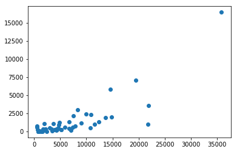

```python
plt.scatter(independent2, dependent)
```

[figure not shown]

```python
plt.scatter(independent3, dependent)
```

```python
import numpy as np
#np.correlate(independent1,dependent, "full")
```

```python
#np.correlate(independent2,dependent)
```

```python
#np.correlate(independent3,dependent)
```

```python
import statsmodels.api as sm
```

```python
model = sm.OLS(dependent, independent2).fit()
predictions = model.predict(dependent)
model.summary()
```

OLS Regression Results

| Dep. Variable: | Adopted Children | R-squared: | 0.698 |
| --- | --- | --- | --- |
| Model: | OLS | Adj. R-squared: | 0.692 |
| Method: | Least Squares | F-statistic: | 115.6 |
| Date: | Wed, 24 Oct 2018 | Prob (F-statistic): | 1.32e-14 |
| Time: | 00:38:40 | Log-Likelihood: | -447.55 |
| No. Observations: | 51 | AIC: | 897.1 |
| Df Residuals: | 50 | BIC: | 899.0 |
| Df Model: | 1 |  |  |
| Covariance Type: | nonrobust |  |  |

|  | coef | std err | t | P>\|t\| | [0.025 | 0.975] |
| --- | --- | --- | --- | --- | --- | --- |
| Same Sex Spouse | 0.2501 | 0.023 | 10.753 | 0.000 | 0.203 | 0.297 |

| Omnibus: | 52.703 | Durbin-Watson: | 2.050 |
| --- | --- | --- | --- |
| Prob(Omnibus): | 0.000 | Jarque-Bera (JB): | 402.235 |
| Skew: | 2.458 | Prob(JB): | 4.53e-88 |
| Kurtosis: | 15.850 | Cond. No. | 1.00 |

Warnings:  
[1] Standard Errors assume that the covariance matrix of the errors is correctly specified.